# Taller: Regresión Logística

## Aprendizaje Supervisado — Clasificación Binaria

**Pontificia Universidad Católica del Ecuador · Carrera de Ingeniería de Sistemas de Información** Asignatura: Inteligencia Artificial

**Nombre del estudiante:** _______________________________________

**Fecha:** _______________________________________

> **Cómo usar este documento:** este archivo es una **guía de referencia** (exportada en HTML) con las explicaciones, el código y los resultados esperados de cada bloque — no es un notebook interactivo. Para completar el taller, reproduce el código en tu propio entorno (Google Colab o Jupyter local) usando el dataset `creditos_ecuador.csv` que se entrega junto con esta guía. Ejecuta las celdas en el mismo orden en que aparecen aquí — no saltes bloques — y compara tus resultados con los que se muestran en este documento.

### Objetivos del taller

Al finalizar este taller el estudiante será capaz de:

1. Explorar un dataset de clasificación binaria usando gráficos.
2. Aplicar el **preprocesamiento correcto** combinando One-Hot Encoding y StandardScaler en un solo objeto (`ColumnTransformer`), y usarlo dentro de un `Pipeline` de scikit-learn para entrenar y predecir sin fuga de datos.
3. Construir y entrenar un modelo de **regresión logística** con scikit-learn.
4. Evaluar el modelo usando **matriz de confusión**, classification report y curva ROC/AUC.
5. Predecir y explicar el resultado para un **caso individual**.
6. Reentrenar el modelo final con el **100% de los datos**, exportarlo con `joblib` como un único `Pipeline` y usarlo para evaluar un cliente nuevo.

### Dataset

Archivo: `creditos_ecuador.csv` — 1 500 solicitudes de crédito de consumo simuladas.

| Variable | Tipo | Descripción |
| --- | --- | --- |
| `edad` | Numérica | Edad en años |
| `ingreso_usd` | Numérica | Ingreso mensual en USD |
| `deuda_actual` | Numérica | Deuda vigente en USD |
| `antiguedad_emp` | Numérica | Años en el empleo actual |
| `provincia` | Categórica | Provincia de residencia |
| `tipo_empleo` | Categórica | Público / Privado / Independiente |
| `historial` | Categórica | Bueno / Regular / Malo |
| `aprobado` | **Objetivo (y)** | 1 = Aprobado · 0 = Rechazado |

### Estructura del taller

| Bloque | Tipo | Contenido |
| --- | --- | --- |
| **A1** | Guiado | Carga y exploración visual |
| **A2** | Guiado | Preprocesamiento: `ColumnTransformer` (OHE + escalado) y división train/test estratificada |
| **A3** | Guiado | `Pipeline` (preprocesamiento + modelo): entrenamiento y predicción |
| **A4** | Guiado | Evaluación: matriz de confusión · classification report · ROC |
| **A5** | Guiado | Predicción de un caso individual con el pipeline |
| **B1** | Autónomo | Modelo sin la variable `historial` (con su propio `ColumnTransformer`) |
| **B2** | Autónomo | Predicción de un nuevo caso individual |
| **C1** | Guiado | Entrenamiento final (100%), exportación del pipeline con `joblib` y uso en producción |

### Rúbrica de evaluación (10 puntos)

| Criterio | Puntos |
| --- | --- |
| **Bloque B1** — Código correcto: `X2`, `preproc2` y `pipeline2` bien construidos, entrenados y evaluados | 2.5 |
| **Bloque B1** — Tabla comparativa completa (Precision, Recall, F1-Score, AUC) | 1.5 |
| **Bloque B1** — Respuestas de análisis: profundidad y justificación con base en los resultados | 1.5 |
| **Bloque B2** — Código correcto: DataFrame del cliente y predicción con el `pipeline` | 1.5 |
| **Bloque B2** — Respuestas de análisis: profundidad y justificación con base en los resultados | 1.5 |
| **Bloques A1–A5 y C1** — Celdas guiadas ejecutadas completas y en orden, sin errores | 1.5 |
| **Total** | **10.0** |

> Los Bloques A1–A5 y C1 son guiados (código provisto): se evalúa que estén reproducidos completos y sin errores en tu propio notebook. Los Bloques B1 y B2 son autónomos: se evalúa la corrección del código y la calidad del análisis escrito.

> **Recuerda:** trabaja en tu propio notebook (Colab o Jupyter), sigue el orden A → B → C, y no saltes bloques.

## Parte A — Laboratorio Guiado

### Bloque A1 · Carga y exploración visual del dataset

**Librerías que usamos en este bloque:**

- `pandas` — carga y manipulación de datos en DataFrames.
- `matplotlib.pyplot` — creación de gráficos estáticos.

**¿Qué hacemos aquí?**  
Antes de construir cualquier modelo es obligatorio explorar los datos.  
Necesitamos conocer: cuántos registros hay, qué tipos de variables existen, si hay valores nulos, y —muy importante— si las clases están **balanceadas**.

Un dataset desbalanceado (por ejemplo 90% rechazados y 10% aprobados) puede hacer que un modelo que siempre predice "Rechazado" tenga 90% de Accuracy, siendo completamente inútil.

```python
import pandas as pd
import matplotlib.pyplot as plt

# Cargar el dataset
df = pd.read_csv('creditos_ecuador.csv')

# Dimensiones del dataset
print(f"Filas: {df.shape[0]}  |  Columnas: {df.shape[1]}")
print()

# Tipos de variables y valores nulos
df.info()
```

```
Filas: 1500  |  Columnas: 8

<class 'pandas.DataFrame'>
RangeIndex: 1500 entries, 0 to 1499
Data columns (total 8 columns):
 #   Column          Non-Null Count  Dtype
---  ------          --------------  -----
 0   edad            1500 non-null   int64
 1   ingreso_usd     1500 non-null   int64
 2   deuda_actual    1500 non-null   int64
 3   antiguedad_emp  1500 non-null   int64
 4   provincia       1500 non-null   str
 5   tipo_empleo     1500 non-null   str
 6   historial       1500 non-null   str
 7   aprobado        1500 non-null   int64
dtypes: int64(5), str(3)
memory usage: 93.9 KB
```

```python
# Primeras filas del dataset
df.head()
```

|  | edad | ingreso_usd | deuda_actual | antiguedad_emp | provincia | tipo_empleo | historial | aprobado |
| --- | --- | --- | --- | --- | --- | --- | --- | --- |
| 0 | 60 | 838 | 1512 | 1 | Guayas | Independiente | Regular | 0 |
| 1 | 50 | 806 | 784 | 0 | Imbabura | Independiente | Bueno | 1 |
| 2 | 36 | 675 | 1417 | 5 | Guayas | Privado | Bueno | 0 |
| 3 | 64 | 350 | 416 | 3 | Guayas | Independiente | Regular | 0 |
| 4 | 29 | 933 | 1704 | 3 | Guayas | Independiente | Regular | 0 |

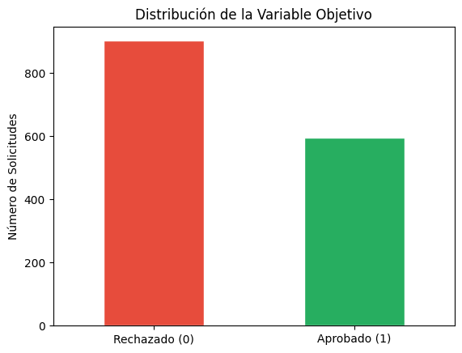

```
Rechazados: 903  (60.2%)
Aprobados:  597  (39.8%)
```

```python
# ── Gráfico 1: Distribución de la variable objetivo ─────────────────────────
conteo = df['aprobado'].value_counts()
pct = df['aprobado'].value_counts(normalize=True) * 100

ax = conteo.plot(kind='bar', color=['#E74C3C', '#27AE60'], edgecolor='white')
ax.set_xticklabels(['Rechazado (0)', 'Aprobado (1)'], rotation=0)
ax.set_xlabel('')
ax.set_title('Distribución de la Variable Objetivo')
ax.set_ylabel('Número de Solicitudes')
plt.show()

print(f"Rechazados: {conteo[0]}  ({pct[0]:.1f}%)")
print(f"Aprobados:  {conteo[1]}  ({pct[1]:.1f}%)")
```

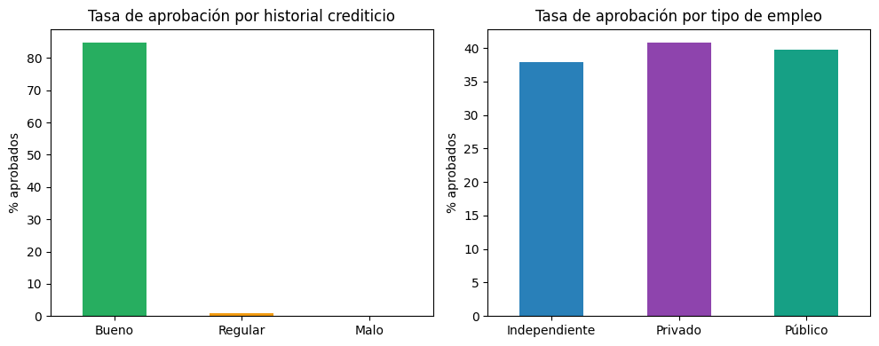

```
% aprobados por historial:
historial
Bueno      84.7
Regular     1.0
Malo        0.0
Name: aprobado, dtype: float64

% aprobados por tipo de empleo:
tipo_empleo
Independiente    37.9
Privado          40.8
Público          39.8
Name: aprobado, dtype: float64

Observación: ¿qué variable parece ser más determinante para la aprobación?
```

```python
# ── Gráfico 2: Tasa de aprobación por historial crediticio y tipo de empleo ──
fig, axes = plt.subplots(1, 2, figsize=(10, 4))

# Por historial crediticio (reindex para mostrarlas en orden Bueno → Regular → Malo)
tasa_hist = df.groupby('historial')['aprobado'].mean().reindex(['Bueno', 'Regular', 'Malo']) * 100
tasa_hist.plot(kind='bar', ax=axes[0], color=['#27AE60', '#F39C12', '#E74C3C'])
axes[0].set_title('Tasa de aprobación por historial crediticio')
axes[0].set_ylabel('% aprobados')
axes[0].set_xlabel('')
axes[0].tick_params(axis='x', rotation=0)

# Por tipo de empleo
tasa_emp = df.groupby('tipo_empleo')['aprobado'].mean() * 100
tasa_emp.plot(kind='bar', ax=axes[1], color=['#2980B9', '#8E44AD', '#16A085'])
axes[1].set_title('Tasa de aprobación por tipo de empleo')
axes[1].set_ylabel('% aprobados')
axes[1].set_xlabel('')
axes[1].tick_params(axis='x', rotation=0)

plt.tight_layout()
plt.show()

print("% aprobados por historial:")
print(tasa_hist.round(1))
print()
print("% aprobados por tipo de empleo:")
print(tasa_emp.round(1))
print()
print("Observación: ¿qué variable parece ser más determinante para la aprobación?")
```

### Bloque A2 · Preprocesamiento — `ColumnTransformer` y división train/test

**Librerías que usamos en este bloque:**

- `sklearn.model_selection.train_test_split` — divide el dataset en entrenamiento (80%) y prueba (20%).
- `sklearn.preprocessing.OneHotEncoder` — convierte variables categóricas en columnas binarias (One-Hot Encoding).
- `sklearn.preprocessing.StandardScaler` — escala las variables numéricas a media 0 y desviación estándar 1.
- `sklearn.compose.ColumnTransformer` — combina el encoder y el scaler en un solo objeto.

**¿Por qué usar `stratify=y` al dividir train/test?** Al dividir el dataset de forma aleatoria, podría ocurrir por azar que el conjunto de entrenamiento quede con una proporción de aprobados distinta a la del conjunto de prueba (por ejemplo, 45% aprobados en `train` pero solo 30% en `test`). Eso complica comparar resultados de forma justa y puede sesgar la evaluación.

`stratify=y` le indica a `train_test_split` que mantenga, tanto en `train` como en `test`, la MISMA proporción de cada clase (aprobado/rechazado) que hay en el dataset completo (~39.8% aprobados). Es una buena práctica estándar al dividir datos para un problema de clasificación, sobre todo cuando las clases no están perfectamente balanceadas.

**¿Por qué aplicar One-Hot Encoding?** La regresión logística trabaja exclusivamente con números. Una variable como `historial` tiene categorías (Bueno, Regular, Malo) que no tienen un orden numérico válido. Si las codificamos como 0, 1, 2, el modelo asume erróneamente que "Malo" = 2 veces "Bueno". Con OHE, cada categoría se convierte en una columna separada de 0 o 1.

El parámetro `drop='first'` elimina una categoría por variable para evitar la **multicolinealidad perfecta** (si conozco todas las columnas menos una, puedo deducirla). `handle_unknown='ignore'` evita que el encoder falle si en producción aparece una categoría que nunca vio durante el entrenamiento.

**¿Por qué escalar las variables numéricas?** La regresión logística usa un algoritmo de optimización basado en gradientes para encontrar sus parámetros. Si `ingreso_usd` está en miles y `edad` en decenas, el algoritmo puede converger más lento. `StandardScaler` transforma cada variable a **(x − media) / desviación estándar**, dejando todas las variables en la misma escala.

**¿Por qué un `ColumnTransformer` en vez de aplicar cada técnica por separado?** `ColumnTransformer` aplica el `OneHotEncoder` **solo** a las columnas categóricas y el `StandardScaler` **solo** a las columnas numéricas, y devuelve el resultado combinado en una sola matriz — un único objeto (`preproc`) en vez de codificar y escalar a mano por separado.

> ⚠️ **Regla de oro:** `preproc` se ajusta (`fit`) **solo** con los datos de entrenamiento. Sobre los datos de prueba (o un cliente nuevo) se aplica únicamente `transform`. Como verás en el Bloque A3, un `Pipeline` se encarga de aplicar esta regla automáticamente — nunca tendrás que llamar `fit`/`transform` a mano.

```python
from sklearn.model_selection import train_test_split
from sklearn.preprocessing import StandardScaler

# 1. Separar variables independientes (X) y variable objetivo (y)
X = df.drop('aprobado', axis=1)
y = df['aprobado']

print(f"X: {X.shape}  |  y: {y.shape}")
```

```
X: (1500, 7)  |  y: (1500,)
```

```python
# 2. División train / test (80% entrenamiento, 20% prueba)
#    Se divide ANTES de codificar/escalar: el ColumnTransformer se ajustará
#    (fit) solo con X_train dentro del Pipeline del Bloque A3.
#    random_state=42 garantiza que siempre obtienes la misma división
#    stratify=y mantiene la misma proporción de aprobados/rechazados en train y test
X_train, X_test, y_train, y_test = train_test_split(
    X, y, test_size=0.2, random_state=42, stratify=y
)

print(f"Entrenamiento: {X_train.shape[0]} filas")
print(f"Prueba:        {X_test.shape[0]} filas")
print()
print(f"% aprobados en entrenamiento: {y_train.mean()*100:.1f}%")
print(f"% aprobados en prueba:        {y_test.mean()*100:.1f}%")
```

```
Entrenamiento: 1200 filas
Prueba:        300 filas

% aprobados en entrenamiento: 39.8%
% aprobados en prueba:        39.7%
```

```python
from sklearn.preprocessing import OneHotEncoder, StandardScaler
from sklearn.compose import ColumnTransformer

# 3. Definir las columnas categóricas y numéricas
cat_cols = ['provincia', 'tipo_empleo', 'historial']
num_cols = ['edad', 'ingreso_usd', 'deuda_actual', 'antiguedad_emp']

# 4. Construir el ColumnTransformer: aplica OHE a las categóricas y
#    StandardScaler a las numéricas, y devuelve todo combinado en una matriz.
preproc = ColumnTransformer([
    ('cat', OneHotEncoder(drop='first', handle_unknown='ignore'), cat_cols),
    ('num', StandardScaler(), num_cols),
])

print("ColumnTransformer 'preproc' definido.")
print("Todavía NO se ha entrenado (fit) — eso ocurre automáticamente en el")
print("Bloque A3, dentro del Pipeline, usando solo X_train.")
```

```
ColumnTransformer 'preproc' definido.
Todavía NO se ha entrenado (fit) — eso ocurre automáticamente en el
Bloque A3, dentro del Pipeline, usando solo X_train.
```

### Bloque A3 · Pipeline, entrenamiento y predicción

**Librerías que usamos en este bloque:**

- `sklearn.pipeline.Pipeline` — encadena el preprocesamiento (`preproc`) y el modelo en un solo objeto.
- `sklearn.linear_model.LogisticRegression` — implementa la regresión logística.

**Parámetros que usamos en `LogisticRegression`:**

- `solver='lbfgs'` — algoritmo de optimización. Es el valor por defecto y funciona bien para datasets de tamaño mediano.
- `max_iter=500` — número máximo de iteraciones. Se sube de 100 (valor por defecto) a 500 como margen de seguridad para asegurar la convergencia.
- `random_state=42` — reproducibilidad de resultados.

**¿Por qué un `Pipeline`?** `Pipeline` encadena `preproc` (Bloque A2) y el modelo en un solo objeto. Al llamar `pipeline.fit(X_train, y_train)`, el pipeline internamente:

1. Ajusta (`fit_transform`) `preproc` **solo** con `X_train`.
2. Entrena el modelo con esos datos ya transformados.

Y al llamar `pipeline.predict(X_test)`, aplica `preproc.transform()` (**nunca** `fit`) sobre `X_test` antes de predecir. La disciplina "fit solo en train" queda garantizada automáticamente — ya no hace falta llamar `fit_transform`/`transform` a mano ni preocuparse de codificar/escalar antes de entrenar.

**`predict` vs `predict_proba`**

El modelo no solo puede decirnos la clase predicha, sino también la **probabilidad** de pertenecer a cada clase:

- `predict(X)` → devuelve directamente la clase (0 o 1), usando el umbral por defecto de **0.5**. Si P(aprobado) ≥ 0.5 → predice 1. Si P(aprobado) < 0.5 → predice 0.
- `predict_proba(X)` → devuelve una tabla con dos columnas:
  - Columna 0: P(y=0 | X) → probabilidad de ser rechazado
  - Columna 1: P(y=1 | X) → probabilidad de ser aprobado

  La suma de ambas columnas siempre es 1.0 para cada fila.

```python
from sklearn.pipeline import Pipeline
from sklearn.linear_model import LogisticRegression

# El Pipeline encadena preproc (Bloque A2) + el modelo en un solo objeto
pipeline = Pipeline([
    ('preproc', preproc),
    ('modelo', LogisticRegression(solver='lbfgs', max_iter=500, random_state=42)),
])

# pipeline.fit() ajusta preproc y entrena el modelo en un solo paso, usando SOLO X_train
pipeline.fit(X_train, y_train)

print("Pipeline entrenado correctamente.")
print(f"Iteraciones necesarias para converger: {pipeline.named_steps['modelo'].n_iter_[0]}")
```

```
Pipeline entrenado correctamente.
Iteraciones necesarias para converger: 20
```

```python
# Predicciones sobre el conjunto de prueba
# pipeline.predict()/predict_proba() aplican preproc.transform() (nunca fit) antes de predecir
y_pred  = pipeline.predict(X_test)              # clase predicha: 0 o 1
y_proba = pipeline.predict_proba(X_test)[:, 1]  # P(aprobado=1 | X)

# Mostrar las primeras 8 predicciones para entender la salida
print("Primeras 8 predicciones del modelo:")
print(f"{'#':<5} {'Real':>6} {'Predicho':>10} {'P(Rechazado)':>14} {'P(Aprobado)':>13}")
print("-" * 52)
for i in range(8):
    p0 = 1 - y_proba[i]
    p1 = y_proba[i]
    correcto = "✓" if y_test.iloc[i] == y_pred[i] else "✗"
    print(f"{i:<5} {y_test.iloc[i]:>6} {y_pred[i]:>10} {p0:>13.3f}  {p1:>12.3f}  {correcto}")

print()
print("Nota: el modelo predice clase 1 (Aprobado) cuando P(Aprobado) >= 0.5")
```

```
Primeras 8 predicciones del modelo:
#       Real   Predicho   P(Rechazado)   P(Aprobado)
----------------------------------------------------
0          0          0         0.994         0.006  ✓
1          0          0         0.554         0.446  ✓
2          1          1         0.423         0.577  ✓
3          1          1         0.002         0.998  ✓
4          0          0         0.998         0.002  ✓
5          0          0         0.999         0.001  ✓
6          0          0         0.995         0.005  ✓
7          1          1         0.027         0.973  ✓

Nota: el modelo predice clase 1 (Aprobado) cuando P(Aprobado) >= 0.5
```

### Bloque A4 · Evaluación del modelo

**Librerías que usamos en este bloque:**

- `sklearn.metrics.confusion_matrix` + `ConfusionMatrixDisplay` — visualiza la matriz de confusión.
- `sklearn.metrics.classification_report` — tabla con Precision, Recall, F1-Score y Accuracy.
- `sklearn.metrics.roc_auc_score` + `roc_curve` — calcula y grafica la curva ROC con su AUC.

#### Matriz de confusión

La matriz de confusión es una tabla que muestra cuántas veces el modelo acertó y en qué tipo de errores incurrió, cruzando los valores **reales** contra los **predichos**:

|  | Predicho: 0 (Rechazado) | Predicho: 1 (Aprobado) |
| --- | --- | --- |
| **Real: 0 (Rechazado)** | **TN** — Verdadero Negativo ✓ | **FP** — Falso Positivo ✗ |
| **Real: 1 (Aprobado)** | **FN** — Falso Negativo ✗ | **TP** — Verdadero Positivo ✓ |

- **TN** (Verdadero Negativo): el modelo predijo Rechazado y el cliente era realmente malo. Correcto.
- **TP** (Verdadero Positivo): el modelo predijo Aprobado y el cliente era realmente bueno. Correcto.
- **FP** (Falso Positivo — Error Tipo I): predijo Aprobado pero el cliente era malo. El banco pierde dinero.
- **FN** (Falso Negativo — Error Tipo II): predijo Rechazado pero el cliente era bueno. El banco pierde un cliente.

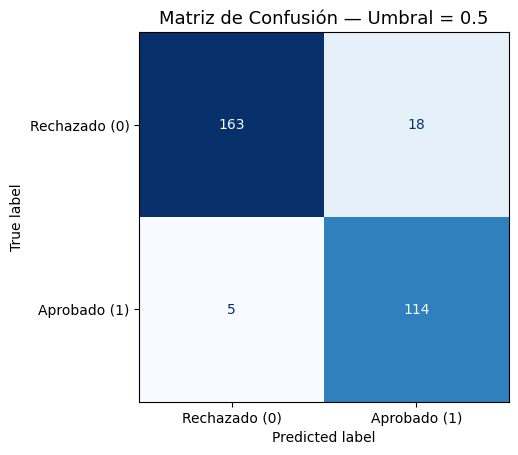

```
TN = 163  |  FP = 18  |  FN = 5  |  TP = 114

Interpretación en el contexto de créditos bancarios:
  Rechazos correctos  (TN): 163  → clientes malos correctamente rechazados
  Aprobaciones correctas (TP): 114  → clientes buenos correctamente aprobados
  Falsos positivos    (FP): 18  → clientes malos que el banco aprobó por error
  Falsos negativos    (FN): 5  → clientes buenos que el banco rechazó por error
```

```python
from sklearn.metrics import (
    confusion_matrix, ConfusionMatrixDisplay,
    classification_report, roc_auc_score, roc_curve
)

# ── Matriz de confusión ──────────────────────────────────────────────────────
cm = confusion_matrix(y_test, y_pred)
disp = ConfusionMatrixDisplay(confusion_matrix=cm,
                               display_labels=['Rechazado (0)', 'Aprobado (1)'])
disp.plot(cmap='Blues', colorbar=False)
plt.title('Matriz de Confusión — Umbral = 0.5', fontsize=13)
plt.show()

tn, fp, fn, tp = cm.ravel()
print(f"TN = {tn}  |  FP = {fp}  |  FN = {fn}  |  TP = {tp}")
print()
print("Interpretación en el contexto de créditos bancarios:")
print(f"  Rechazos correctos  (TN): {tn}  → clientes malos correctamente rechazados")
print(f"  Aprobaciones correctas (TP): {tp}  → clientes buenos correctamente aprobados")
print(f"  Falsos positivos    (FP): {fp}  → clientes malos que el banco aprobó por error")
print(f"  Falsos negativos    (FN): {fn}  → clientes buenos que el banco rechazó por error")
```

#### Classification Report

El `classification_report` resume en una sola tabla las principales métricas del modelo. Veamos cómo interpretar **cada columna** y **cada fila**:

**Columnas:**

- **precision** — De todos los que el modelo predijo como clase X, ¿qué proporción realmente eran clase X?  
  `Precision = TP / (TP + FP)`  
  Alta precision → pocas falsas alarmas.
- **recall** — De todos los que realmente son clase X, ¿qué proporción detectó el modelo?  
  `Recall = TP / (TP + FN)`  
  Alto recall → el modelo detecta la mayoría de los casos reales.
- **f1-score** — Media armónica entre precision y recall. Útil cuando las clases están desbalanceadas.  
  `F1 = 2 × (Precision × Recall) / (Precision + Recall)`
- **support** — Número real de instancias de esa clase en el conjunto de prueba.

**Filas:**

- **0 (Rechazado)** — métricas para la clase negativa.
- **1 (Aprobado)** — métricas para la clase positiva (la que nos interesa detectar).
- **accuracy** — proporción total de predicciones correctas sobre todas las predicciones.
- **macro avg** — promedio simple de las métricas de cada clase (ignora el desbalance).
- **weighted avg** — promedio ponderado por el número de instancias de cada clase (tiene en cuenta el desbalance).

```python
# ── Classification Report ───────────────────────────────────────────────────
print("=== Classification Report ===")
print(classification_report(y_test, y_pred,
                             target_names=['Rechazado (0)', 'Aprobado (1)']))
```

```
=== Classification Report ===
               precision    recall  f1-score   support

Rechazado (0)       0.97      0.90      0.93       181
 Aprobado (1)       0.86      0.96      0.91       119

     accuracy                           0.92       300
    macro avg       0.92      0.93      0.92       300
 weighted avg       0.93      0.92      0.92       300
```

#### Curva ROC y AUC

La curva ROC muestra el rendimiento del modelo a **todos los umbrales posibles** de clasificación.  
Cada punto de la curva representa un umbral diferente y muestra:

- **TPR (Tasa de Verdaderos Positivos = Recall)** en el eje Y: ¿cuántos positivos reales detecta?
- **FPR (Tasa de Falsos Positivos)** en el eje X: ¿cuántos negativos clasifica mal como positivos?

El **AUC** (Área Bajo la Curva) resume la curva en un solo número:

- AUC = 1.0 → modelo perfecto (no existe en la práctica)
- AUC ≥ 0.9 → excelente · AUC 0.8–0.9 → muy bueno · AUC 0.7–0.8 → aceptable
- AUC = 0.5 → equivale a clasificar al azar (la línea diagonal punteada)

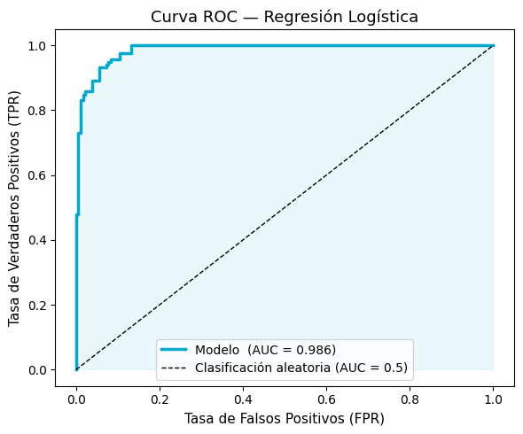

```
AUC = 0.986
→ Modelo EXCELENTE
```

```python
# ── Curva ROC y AUC ─────────────────────────────────────────────────────────
fpr, tpr, thresholds = roc_curve(y_test, y_proba)
auc = roc_auc_score(y_test, y_proba)

plt.figure(figsize=(6, 5))
plt.plot(fpr, tpr, color='#00A9CE', linewidth=2.5, label=f'Modelo  (AUC = {auc:.3f})')
plt.plot([0, 1], [0, 1], 'k--', linewidth=1, label='Clasificación aleatoria (AUC = 0.5)')
plt.fill_between(fpr, tpr, alpha=0.08, color='#00A9CE')
plt.xlabel('Tasa de Falsos Positivos (FPR)', fontsize=11)
plt.ylabel('Tasa de Verdaderos Positivos (TPR)', fontsize=11)
plt.title('Curva ROC — Regresión Logística', fontsize=13)
plt.legend(fontsize=10)
plt.tight_layout()
plt.show()

print(f"AUC = {auc:.3f}")
if auc >= 0.9:
    print("→ Modelo EXCELENTE")
elif auc >= 0.8:
    print("→ Modelo MUY BUENO")
elif auc >= 0.7:
    print("→ Modelo ACEPTABLE")
else:
    print("→ Modelo DÉBIL — revisar las variables del dataset")
```

### Bloque A5 · Predicción de un caso individual

**¿Qué hacemos aquí?** El modelo está entrenado. Ahora simulamos que llega un nuevo cliente al banco y queremos saber si el modelo lo aprobaría o rechazaría — y con qué probabilidad.

**Pasos para predecir un caso nuevo:**

1. Crear un DataFrame con los datos del cliente (mismas columnas que el dataset original, **sin codificar**).
2. Predecir directamente con `pipeline.predict()` / `pipeline.predict_proba()`.

Como `pipeline` ya incluye `preproc` (Bloque A2, entrenado), **no hace falta** aplicar manualmente One-Hot Encoding, alinear columnas con `reindex` ni escalar — el pipeline hace todo internamente, con el mismo `preproc` que ya conoce las categorías del entrenamiento.

> ⚠️ **Por qué esto importa:** aplicar `pd.get_dummies` directamente sobre un DataFrame de una sola fila (un único cliente) es un error real y silencioso. Con una sola fila, cada columna categórica solo tiene UNA categoría presente, así que `drop_first`/`drop='first'` la elimina por completo — el cliente terminaría codificado como si todas sus variables categóricas fueran la categoría base, sin importar su valor real, y no se lanza ningún error ni advertencia. El `OneHotEncoder` dentro de `preproc` no tiene este problema porque ya "memorizó" las categorías durante el entrenamiento — no las vuelve a derivar de la fila que recibe.

**Datos del cliente:**

| Variable | Valor |
| --- | --- |
| Edad | 38 años |
| Ingreso mensual | $1,450 USD |
| Deuda actual | $800 USD |
| Antigüedad en el empleo | 9 años |
| Provincia | Pichincha |
| Tipo de empleo | Público |
| Historial crediticio | Bueno |

```python
# Datos del cliente nuevo
cliente = pd.DataFrame({
    'edad':           [38],
    'ingreso_usd':    [1450],
    'deuda_actual':   [800],
    'antiguedad_emp': [9],
    'provincia':      ['Pichincha'],
    'tipo_empleo':    ['Público'],
    'historial':      ['Bueno']
})

print("Datos del cliente:")
print(cliente.to_string(index=False))
```

```
Datos del cliente:
 edad  ingreso_usd  deuda_actual  antiguedad_emp provincia tipo_empleo historial
   38         1450           800               9 Pichincha     Público     Bueno
```

```python
# Predecir directamente sobre el DataFrame crudo del cliente (sin OHE ni escalado manual)
# pipeline.predict()/predict_proba() aplican preproc.transform() (nunca fit) por dentro
clase_pred = pipeline.predict(cliente)
proba_pred = pipeline.predict_proba(cliente)

print("=" * 45)
print("       RESULTADO DE LA EVALUACIÓN")
print("=" * 45)
print(f"  Clase predicha:       {'Aprobado ✓' if clase_pred[0] == 1 else 'Rechazado ✗'}")
print(f"  P(Rechazado):         {proba_pred[0][0]:.3f}  ({proba_pred[0][0]*100:.1f}%)")
print(f"  P(Aprobado):          {proba_pred[0][1]:.3f}  ({proba_pred[0][1]*100:.1f}%)")
print("=" * 45)
print()
print("Interpretación:")
print(f"  El modelo predice que este cliente tiene un {proba_pred[0][1]*100:.1f}% de")
print(f"  probabilidad de cumplir con el crédito.")
print()
print("  Factores que favorecen la aprobación:")
print("  → Historial crediticio: Bueno")
print("  → Antigüedad en el empleo: 9 años (estabilidad laboral)")
print("  → Relación deuda/ingreso: baja ($800 deuda vs $1,450 ingreso)")
```

```
=============================================
       RESULTADO DE LA EVALUACIÓN
=============================================
  Clase predicha:       Aprobado ✓
  P(Rechazado):         0.001  (0.1%)
  P(Aprobado):          0.999  (99.9%)
=============================================

Interpretación:
  El modelo predice que este cliente tiene un 99.9% de
  probabilidad de cumplir con el crédito.

  Factores que favorecen la aprobación:
  → Historial crediticio: Bueno
  → Antigüedad en el empleo: 9 años (estabilidad laboral)
  → Relación deuda/ingreso: baja ($800 deuda vs $1,450 ingreso)
```

## Parte B — Práctica Autónoma

> En esta parte **no se provee código completo**. Usa exactamente los mismos pasos que aplicaste en la Parte A. En tu propio notebook (Colab o Jupyter), escribe el código que reemplace cada `# TODO` que ves en esta guía, y responde las preguntas de análisis en tu propio notebook.

### Bloque B1 · Modelo sin la variable `historial`

**Tu tarea:**

1. Crea un nuevo `X2` eliminando la columna `historial` (la columna original, sin codificar).
2. Crea un nuevo `preproc2` (un `ColumnTransformer`) con las mismas columnas categóricas MENOS `historial`, y las mismas columnas numéricas.
3. Arma un `pipeline2` con `preproc2` y un nuevo modelo, y entrénalo.
4. Predice sobre el conjunto de prueba.
5. Evalúa el modelo con matriz de confusión y classification report.
6. Compara con los resultados del Bloque A4 y responde las preguntas.

```python
from sklearn.compose import ColumnTransformer
from sklearn.preprocessing import OneHotEncoder, StandardScaler
from sklearn.pipeline import Pipeline
from sklearn.linear_model import LogisticRegression
from sklearn.model_selection import train_test_split
from sklearn.metrics import confusion_matrix, ConfusionMatrixDisplay, classification_report

# TODO 1: Crear X2 eliminando la columna 'historial' (columna original, sin codificar)
# Pista: usa X.drop(columns=[...])
X2 = None  # reemplaza None con tu código

print(f"Columnas en X original: {X.shape[1]}")
# print(f"Columnas en X2 (sin historial): {X2.shape[1]}")
```

```
Columnas en X original: 7
```

```python
# TODO 2: División train/test (usa el mismo random_state=42 y stratify=y
# para comparar justamente con el Bloque A4 — ver la explicación de stratify en A2)
X2_train, X2_test, y2_train, y2_test = None, None, None, None
# train_test_split(X2, y, test_size=0.2, random_state=42, stratify=y)
```

```python
# TODO 3: Crear preproc2 — igual que preproc en A2, pero SIN 'historial' en las categóricas
cat_cols2 = ['provincia', 'tipo_empleo']  # ya sin 'historial'
num_cols2 = ['edad', 'ingreso_usd', 'deuda_actual', 'antiguedad_emp']

preproc2 = None
# ColumnTransformer([
#     ('cat', OneHotEncoder(drop='first', handle_unknown='ignore'), cat_cols2),
#     ('num', StandardScaler(), num_cols2),
# ])
```

```python
# TODO 4: Armar el pipeline2 (preproc2 + un nuevo modelo) y entrenarlo
modelo2 = LogisticRegression(solver='lbfgs', max_iter=500, random_state=42)
pipeline2 = None
# Pipeline([('preproc', preproc2), ('modelo', modelo2)])

# pipeline2.fit(...)  # entrena con X2_train, y2_train
```

```python
# TODO 5: Predecir
y2_pred  = None  # pipeline2.predict(...)
y2_proba = None  # pipeline2.predict_proba(...)[:, 1]
```

```python
# TODO 6: Mostrar la matriz de confusión
# Usa ConfusionMatrixDisplay igual que en el Bloque A4
# Añade un título que diga "Sin variable historial"
```

```python
# TODO 7: Mostrar el classification report
# print(classification_report(..., target_names=['Rechazado (0)', 'Aprobado (1)']))
```

**Análisis comparativo — completa la tabla con tus resultados:**

| Métrica (clase Aprobado) | Modelo completo (A4) | Modelo sin historial (B1) | Diferencia |
| --- | --- | --- | --- |
| Precision |  |  |  |
| Recall |  |  |  |
| F1-Score |  |  |  |
| AUC |  |  |  |

**Preguntas:**

1. ¿Cuánto bajó el F1-Score al eliminar `historial`? ¿Es una caída grande o pequeña?
2. ¿Qué métrica se afectó más — Precision o Recall? ¿A qué se debe?
3. ¿Podría un banco usar un modelo sin historial crediticio? ¿En qué situación tendría sentido?

*(escribe tu respuesta aquí)*

### Bloque B2 · Predicción de un nuevo caso individual

**Contexto:** Aplica el `pipeline` original (entrenado en A3) para evaluar a un nuevo solicitante de crédito. Debes seguir exactamente los mismos pasos del Bloque A5.

**Datos del nuevo cliente:**

| Variable | Valor |
| --- | --- |
| Edad | 27 años |
| Ingreso mensual | $620 USD |
| Deuda actual | $3,800 USD |
| Antigüedad en el empleo | 1 año |
| Provincia | Guayas |
| Tipo de empleo | Privado |
| Historial crediticio | Regular |

**Tu tarea:**

1. Construye el DataFrame del cliente (columnas **sin codificar**, igual que en A5).
2. Predice la clase y la probabilidad directamente con `pipeline.predict()` / `pipeline.predict_proba()` — sin aplicar OHE ni escalado a mano.
3. Responde las preguntas de análisis.

```python
# TODO 1: Crear el DataFrame del nuevo cliente
# Usa exactamente las mismas columnas que el dataset original (SIN codificar)
cliente2 = pd.DataFrame({
    # completa con los datos del cliente indicados arriba
})

# TODO 2: Predecir clase y probabilidad directamente con el pipeline
# (el pipeline ya incluye preproc — no se aplica OHE ni escalado a mano)
clase2 = None  # pipeline.predict(cliente2)
proba2 = None  # pipeline.predict_proba(cliente2)

# TODO 3: Mostrar el resultado con formato claro
# Imprime: clase predicha, P(Rechazado) y P(Aprobado)
```

**Responde:**

1. ¿El modelo aprueba o rechaza a este cliente? ¿Con qué probabilidad?
2. Compara este cliente con el del Bloque A5. ¿Qué variables concretas explican la diferencia en el resultado?
3. Si fueras analista del banco, ¿aprobarías el crédito? Justifica tu respuesta más allá de lo que dice el modelo.

## Parte C — Entrenamiento Final, Exportación y Uso del Modelo

> Cierra el ciclo completo: de un pipeline evaluado en un notebook, a un archivo listo para usarse en cualquier otro programa.

### Bloque C1 · Entrenamiento final, exportación y uso del modelo

**¿Por qué reentrenar?**

El pipeline de los Bloques A3–A4 se entrenó solo con el 80% de los datos (`X_train`); el 20% restante (`X_test`) se reservó únicamente para **medir** qué tan bien generaliza el modelo a datos que no vio.

Una vez aprobado ese resultado, el pipeline que se usaría en producción **se reentrena con el 100% de los datos disponibles** — ya no necesita guardar un conjunto de prueba propio, porque su desempeño ya se estimó en el paso anterior. Más datos de entrenamiento generalmente producen un modelo mejor.

**Librería que usamos en este bloque:**

- `joblib` — guarda y carga objetos de Python (como un pipeline entrenado) en un archivo `.pkl`.

**¿Por qué exportar `pipeline_final` completo, y no el modelo y el preprocesamiento por separado?**

`pipeline_final` incluye **tanto** `preproc` **como** el modelo, en un solo objeto. Al exportarlo con `joblib.dump()`, un único archivo `.pkl` contiene todo lo necesario — no hay riesgo de guardar el modelo junto a un `preproc` distinto, ni de cargarlos en el orden equivocado.

```python
from sklearn.pipeline import Pipeline
from sklearn.linear_model import LogisticRegression
import joblib

# 1. y ya representa el objetivo completo (0 = rechazado, 1 = aprobado); X ya existe
#    (sin codificar) desde el Bloque A2 — aquí se reentrena con el 100%, no solo X_train.

# 2. Armar el pipeline final: mismo preproc del Bloque A2, modelo nuevo (se entrena
#    desde cero con el dataset completo)
pipeline_final = Pipeline([
    ('preproc', preproc),
    ('modelo', LogisticRegression(solver='lbfgs', max_iter=500, random_state=42)),
])

# 3. Entrenar con el 100% de los datos (X completo, no solo X_train)
pipeline_final.fit(X, y)

print(f"Pipeline final entrenado con {X.shape[0]} registros (100% del dataset).")
print(f"Iteraciones necesarias para converger: {pipeline_final.named_steps['modelo'].n_iter_[0]}")
```

```
Pipeline final entrenado con 1500 registros (100% del dataset).
Iteraciones necesarias para converger: 20
```

```python
# Exportar el pipeline final completo (preproc + modelo) en un solo archivo
joblib.dump(pipeline_final, 'modelo_creditos.pkl')
print("Pipeline exportado como 'modelo_creditos.pkl'")
```

```
Pipeline exportado como 'modelo_creditos.pkl'
```

### Usar el modelo exportado con un cliente nuevo

Ahora simulamos que este archivo `.pkl` se usa desde **otro programa**, sin el notebook de entrenamiento — por ejemplo, el mismo escenario de la unidad de Despliegue de Modelos, donde este archivo se cargaría una sola vez dentro de una API.

**Datos del cliente nuevo:**

| Variable | Valor |
| --- | --- |
| Edad | 33 años |
| Ingreso mensual | $980 USD |
| Deuda actual | $1,200 USD |
| Antigüedad en el empleo | 4 años |
| Provincia | Azuay |
| Tipo de empleo | Privado |
| Historial crediticio | Bueno |

```python
# Paso 1: Cargar el pipeline exportado (como lo haría otro programa)
pipeline_prod = joblib.load('modelo_creditos.pkl')

# Paso 2: Construir el DataFrame del cliente nuevo (columnas SIN codificar)
cliente_nuevo = pd.DataFrame({
    'edad': [33],
    'ingreso_usd': [980],
    'deuda_actual': [1200],
    'antiguedad_emp': [4],
    'provincia': ['Azuay'],
    'tipo_empleo': ['Privado'],
    'historial': ['Bueno']
})

# Paso 3: Predecir directamente — pipeline_prod ya incluye preproc por dentro,
# no hace falta aplicar OHE, alinear columnas ni escalar a mano
clase_pred = pipeline_prod.predict(cliente_nuevo)
proba_pred = pipeline_prod.predict_proba(cliente_nuevo)

print("=" * 45)
print("  RESULTADO DE LA EVALUACIÓN (modelo de producción)")
print("=" * 45)
print(f"  Clase predicha: {'Aprobado ✓' if clase_pred[0] == 1 else 'Rechazado ✗'}")
print(f"  P(Rechazado): {proba_pred[0][0]:.3f}  ({proba_pred[0][0]*100:.1f}%)")
print(f"  P(Aprobado):  {proba_pred[0][1]:.3f}  ({proba_pred[0][1]*100:.1f}%)")
print("=" * 45)
```

```
=============================================
  RESULTADO DE LA EVALUACIÓN (modelo de producción)
=============================================
  Clase predicha: Aprobado ✓
  P(Rechazado): 0.037  (3.7%)
  P(Aprobado):  0.963  (96.3%)
=============================================
```

**Para reflexionar:**

1. El archivo `modelo_creditos.pkl` ya no depende de este notebook ni del dataset original — ¿qué contiene exactamente ese único objeto `pipeline_final`? (Pista: revisa qué pasos tiene un `Pipeline`.)
2. ¿Por qué el pipeline de producción (Bloque C1) ya no separa datos de prueba, mientras que el de los Bloques A3–A4 sí lo hacía?
3. Compara la probabilidad de este cliente con la del cliente del Bloque A5. ¿Qué variable explica mejor la diferencia?